# As-a-Statistician-Advanced Linear Regression

Zehui Bai

2022-12-19 14:50:06

[interactive chart not shown]

## Model Selection

### Selection Methods

**1. Forward stepwise selection**

Forward stepwise selection: Start with a zero-feature model, and then add one feature at a time until all features are added. In this process, the model created by the selected features that are added has the smallest RSS. So in theory, the first selected feature should best explain the response variable, and so on. **Adding a feature will definitely reduce the RSS** and **increase the R-square**, but it will not necessarily improve the fit and interpretability of the model

> 前向逐步选择: 从一个零特征模型开始，然后每次添加一个特征，直到所有特征添加完毕。在 这个过程中，被添加的选定特征建立的模型具有最小的RSS。所以理论上，第一个选定的特征应 该能最好地解释响应变量，依此类推。添加一个特征一定会使RSS减少，使R方增加，但不一定能提高模型的拟合度和 可解释性

```
title2 ’Forward stepwise selection’;
proc reg;
model birthwt = headcirc length gestage momage toxemia
/ selection=f;
run;
```

**2. Backward stepwise regression**

Backward stepwise regression starts with a model that includes all features, and deletes one feature that plays the smallest role each time

> 后向逐步回归从一个包含所有特征的模型开始，每次删除一个起最小作用的特征。现在也有 一种混合方法，这种算法先通过前向逐步回归添加特征，然后检查是否有特征不再对提高模型拟 合度起作用，如果有则删除。每次建模之后，分析者都可以检查模型输出， 并使用各种统计量选择能提供最佳拟合的特征. 某些逐步回归的支持者更喜欢向后方法，因为每个解释变量都有机会被包含在最终选择的模型中。

> 逐步回归技术会遇到非常严重的问题。 对于一个数据集，先用前向逐步回归，然后再用后向逐步回归，可能会得到两个完全矛盾的模型。 最重要的一点是，逐步回归会使回归系数发生偏离，换句话说，会使回归系数的值过大，置信区间过窄(Tibrishani，1996)

```
proc reg;
model birthwt = headcirc length gestage momage toxemia
/ selection=b;
run;
```

**3. Best subset regression**

> 最优子集回归是逐步回归的一个可接受的替代方案。在最优子集回归中，算法使用所有可能的特征组合来拟合模型，所以，如果有3个特征，将生成7个模型。然后和逐步回 归一样，分析者需要应用自己的判断和统计分析来选择最优模型，模型选择就是后面工作的关键。 如果数据集有多个特征，工作量就会非常大。当特征数多于观测数时(p大 于n)，这个方法的效果就不会好。

```
title2 ’Selecting the best of all possible regression models’;
proc reg;
model birthwt = headcirc length gestage momage toxemia
/ selection=cp adjrsq r best=5;
run;
```

> / selection = cp adjrsq r选项指示SAS使用Cp准则排序最佳模型，并列出调整后和未经调整的R2统计信息。 best =选项指定SAS在检查所有可能的解释变量选择后将列出的最大数量的不同模型。

```
library(leaps)
library(alr3)
data(water)
socal.water <- water[ ,-1]


## Full Model
fit <- lm(BSAAM ~ ., data = socal.water)
summary(fit)

sub.fit <- regsubsets(BSAAM ~ ., data = socal.water)
best.summary <- summary(sub.fit)
best.summary


## A model with a minimum and maximum value of a certain output.
which.min()
which.max()

names(best.summary)
which.min(best.summary$rss)
which.min(best.summary$bic)
which.max(best.summary$adjr2)


## Plot model evaluation
par(mfrow = c(1,2))
plot(best.summary$cp, xlab = "number of features", ylab = "cp")
plot(sub.fit, scale = "Cp")
```

### Selection Criteria

**1. Akaike information criterion (AIC)**

$$A I C=2 k-2 \ln (\hat{L})$$

- $k$ = number of estimated parameters in the model
- $\hat{L}$ = maximum value of the likelihood function for the model

**2. Bayesian information criterion (BIC)**

or Schwarz information criterion (also SIC, SBC, SBIC)

$${\displaystyle \mathrm {BIC} =k\ln(n)-2\ln({\widehat {L}}).\ }$$

- $n$ = the number of data points in ${\displaystyle x}$, the number of observations, or equivalently, the sample size;

**3. Adjusted $R^2$**

Adjusted $R^2$ statistic takes the number of explanatory variables p into account. The definition is
$$\text { Adjusted }\left(R^{2}\right)=1-\frac{(N-1)\left(1-R^{2}\right)}{N-p}$$

p is the number of parameters in the model, and N is the sample size. **If the sample size N is much larger than the number of explanatory variables**, the adjusted $R^2$ will not be very different from the usual R2.

**4. Mallows’s Cp**

$$C_{p}=\frac{\text { Error SS(p parameters) }}{s^{2}(\text { for the full model })}-N+2 p,$$

This statistic is used to compare the “full” model with all explanatory variables to a smaller model with p-parameters. It is best to use smaller Cp values, because they mean that the root mean square error of the model is smaller, and that there are fewer terms in the model

**Other common metrics**

- MAPE (Mean absolute percentage error) $\rightarrow$ Lower the better
- MSE (Mean squared error) $\rightarrow$ Lower the better

### k- Fold Cross validation

> 美国莱特州立大学的塔皮教授对此有精彩的论述: 我们经常使用回归模型预测未来观测值。我们用数据去拟合模型是完全可以的， 但如果用来预测模型响应的数据和用来估计模型的数据属于同一批，那么说预测效果有多么好就有欺骗的嫌疑了。 在评价模型对未来观测值的预测效果方面，这样做往往会得 到过于乐观的结果。如果我们留下一个观测值，用其余观测值拟合模型， 然后再预测这个留下的观测值，那么评价模型预测效果时，得到的结论会具有更少偏差。

Suppose, the model predicts satisfactorily on the 20% split (test data), is that enough to believe that your model will perform equally well all the time? It is important to rigorously test the model’s performance as much as possible. One way is to ensure that the model equation you have will perform well, when it is ‘built’ on a different subset of training data and predicted on the remaining data.

Split your data into ‘k’ mutually exclusive random sample portions. Keeping each portion as test data, we build the model on the remaining (k-1 portion) data and calculate the mean squared error of the predictions. This is done for each of the ‘k’ random sample portions. Then finally, the average of these mean squared errors (for ‘k’ portions) is computed. We can use this metric to compare different linear models.

```r
## CVlm {DAAG}
## Cross-Validation for Linear Regression

library(DAAG)
data(cars)
# performs the CV
cvResults <- suppressWarnings(CVlm(data =cars,
                                   form.lm=dist ~ speed,
                                   m=5,
                                   dots=FALSE,
                                   seed=29,
                                   legend.pos="topleft",
                                   printit=FALSE,
                                   main="Small symbols are predicted values while bigger ones are actuals."))
```

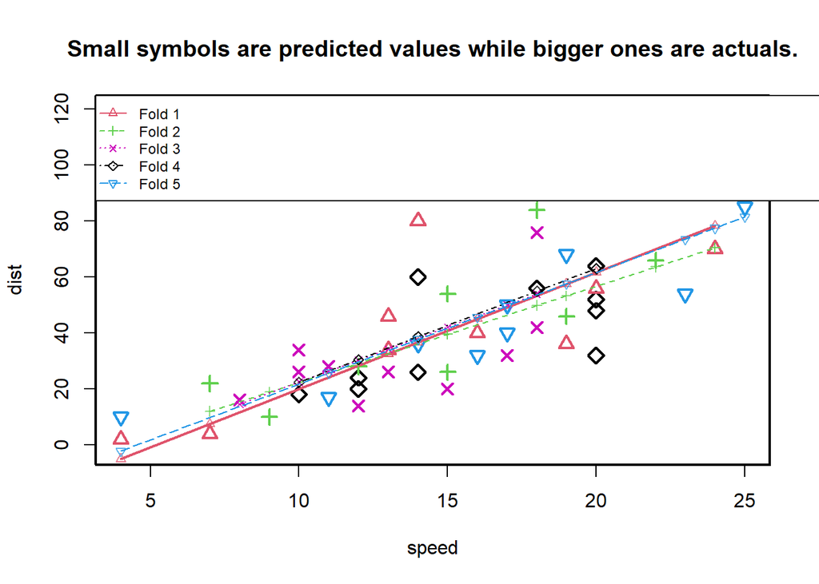

```r
## mean squared error
attr(cvResults, 'ms')
```

```
## [1] 254.2661
```

```r
## Check plot, Are the dashed lines parallel? Are the small and big symbols are not over dispersed for one particular color?
```

**predicted residual error sum of squares (PRESS)**

The predicted residual error sum of squares (PRESS) statistic is a form of cross-validation used in regression analysis to provide a summary measure of the fit of a model to a sample of observations that were not themselves used to estimate the model. It is calculated as the sums of squares of the prediction residuals for those observations.

A fitted model having been produced, each observation in turn is removed and the model is refitted using the remaining observations. The out-of-sample predicted value is calculated for the omitted observation in each case, and the PRESS statistic is calculated as the sum of the squares of all the resulting prediction errors

$$\operatorname {PRESS}=\sum _{{i=1}}^{n}(y_{i}-{\hat {y}}_{{i,-i}})^{2}$$

> 预测的残差平方和（PRESS）统计量是一种交叉验证的一种形式，用于回归分析，以提供模型对自身不用于估计模型的观测值样本拟合的汇总度量。 它被计算为这些观测值的预测残差的平方和。已生成拟合模型，依次删除每个观察值，并使用其余观察值重新拟合模型。 在每种情况下，都会为省略的观察计算出样本外预测值，并且将PRESS统计量计算为所有产生的预测误差的平方和

```
library(MPV)
PRESS(lm(dist ~ speed,data =cars))
```

## Practical Difficulties using OLS

**1. Nonrandom Samples**

数据的收集方式直接影响我们可以得出的结论。假设检验的一般理论提出了一个从中抽取样本的总体。样本就是我们的数据，我们想使用从样本数据中获得的估计值来说明未知的总体值！此外，我们要求生成数据d使用总体的简单随机样本。该样本的大小是有限的，而总体的大小是无限的，或者至少如此之大，以至于样本量在整体中所占的比例可以忽略不计。当数据根本不是随机样本时，统计推断背后的逻辑还取决于样本是随机的。这并不是说这样的研究是毫无价值的，而是应用描述性的统计技术之外的其他任何东西都是不合理的。对此类数据得出的结论的置信度肯定值得怀疑

**2. Choice and Range of Predictors**

如果未观察到重要的预测因素，则预测可能会很差，或者我们可能会误解预测因素与响应之间的关系。数据收集的范围和条件可能会限制有效的预测。 推断太多是不安全的。

**3. Model Misspecification**

我们对模型的结构部分和随机部分进行假设。 $\varepsilon \sim \mathrm{N}\left(0, \sigma^{2} I\right)$ 但这可能不正确. 线性模型 $E y=X \beta$ 的结构部分也可能不正确。

**4. Practical and Statistical Significance**

统计意义不等于实际意义。样本越大，您的p值将越小，因此请不要将p值与重要的预测器效果混淆。对于大型数据集，将很容易获得具有统计意义的结果，但实际效果可能并不重要。

参数估计值上的CIS是评估效果大小的更好方法。即使在不拒绝零假设的情况下，它们也很有用，因为它们告诉我们，我们对真实效果或价值接近零的信心有多强。同样重要的是要记住，模型通常只是基础现实的近似，这至少使参数的确切含义值得商榷. 此外，我们知道，拥有的数据越多，测试的功能就越强大。即使是零样本，即使有很大的差异，也会被大量样本检测到。现在，如果我们不能拒绝原假设，我们可能会简单地得出结论，即我们没有足够的数据来获得重要的结果。根据这种观点，假设检验只是对样本量的检验。因此，我们更喜欢CIs

## Skewness

### Introduction

Skewness is a measure of symmetry for a distribution. The value can be positive, negative or undefined. In a skewed distribution, the central tendency measures (mean, median, mode) will not be equal.

- Positively skewed distribution (or right skewed): The most frequent values are low; tail is toward the high values (on the right-hand side). Generally, Mode < Median < Mean.
- Negatively skewed distribution (or left skewed), the most frequent values are high; tail is toward low values (on the left-hand side). Generally, Mode > Median > Mean.

**skewness value**

The direction of skewness is given by the sign of the skewness coefficient: The larger the value of skewness, the larger the distribution differs from a normal distribution

- A zero means no skewness at all (normal distribution).
- A negative value means the distribution is negatively skewed.
- A positive value means the distribution is positively skewed.

```
library(moments)
skewness(iris$Sepal.Length, na.rm = TRUE)
```

**Visualization**

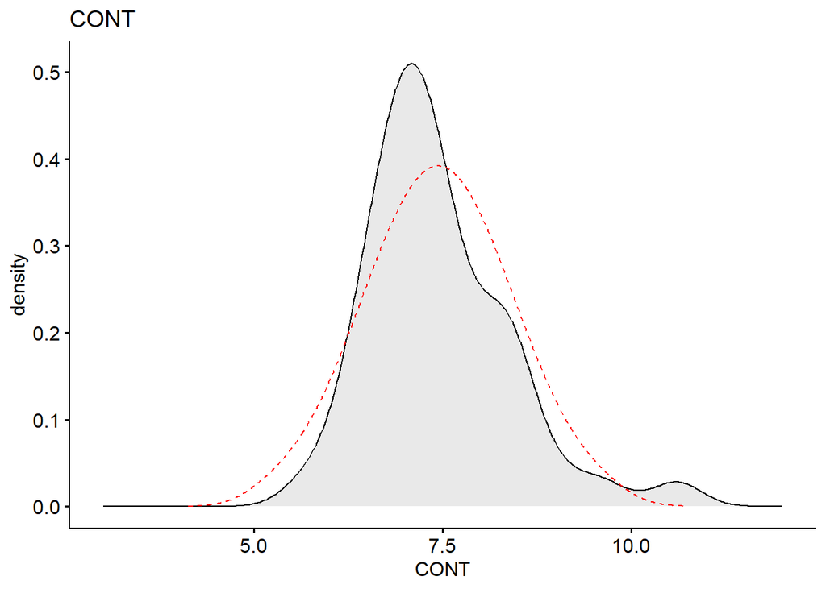

```r
## ggpubr for creating easily publication ready plots
## moments for computing skewness
library(moments)
library(ggpubr)
data("USJudgeRatings")
df <- USJudgeRatings

## Consider two variables:
## CONT: Number of contacts of lawyer with judge. Positively skewed.
## 律师与法官的联系次数。正偏
## PHYS: Physical ability. Negatively skewed 身体能力。负偏斜

## Visualization
## The “CONT” variable shows positive skewness. “PHYS” variable is negatively skewed
## Distribution of CONT variable
ggdensity(df, x = "CONT", fill = "lightgray", title = "CONT") +
  scale_x_continuous(limits = c(3, 12)) +
  stat_overlay_normal_density(color = "red", linetype = "dashed")
```

### Baisc Transformation

- square-root for moderate skew:
  - sqrt(x) for positively skewed data,
  - sqrt(max(x+1) - x) for negatively skewed data
- log for greater skew: The logarithm transformation of any variable will pull in large values and spread apart the low values 任何变量的对数转换将拉大值并分散低值
  - log10(x) for positively skewed data,
  - log10(max(x+1) - x) for negatively skewed data
- inverse for severe skew:
  - 1/x for positively skewed data
  - 1/(max(x+1) - x) for negatively skewed data

**Attention**

在不满足正态性假设的情况下，您可以考虑对已转换和未转换的数据运行统计检验（t检验或ANOVA），以查看是否存在任何有意义的差异。 如果两个测试都得出相同的结论，则您可能不选择转换结果变量并继续对原始数据进行测试输出。

注意，转换会使分析变得更加困难。例如，如果在转换数据后运行t检验以比较两组的平均值，则不能简单地说两组的均值存在差异。 现在，您具有附加的步骤来解释差异是基于对数转换的事实。因此，通常除非要使分析有效就必须避免进行转换。

假设响应变量y是连续的，仅假定为正值，并且其直方图似乎不是大致对称且呈钟形（即normal），而是具有较长的右尾 but rather has a long right tail （向右偏斜）。 我们讨论了对这种响应进行建模的两种可能的方法：Box-Cox变换和伽马回归。

### Box-Cox Power Transformation

If the density of the response variable y is shifted to the right, you can transform y to make its density look more normal.

$$\tilde{y}=\left\{\begin{array}{ll}
\frac{y^{\lambda}-1}{\lambda}, & \text { if } \lambda \neq 0 \\
\ln y, & \text { if } \lambda=0
\end{array}\right.$$

$\lambda$的最佳值借助于最大似然估计来找到。对于一组离散的$\lambda$值, 拟合一个线性模型, 其中变换后的响应$y$回归到预测变量 $x_{1}, \ldots, x_{k}$ 选择与似然函数的最大值相对应的 $\lambda$的值作为最佳值。但是, 所描述的优化是在y 正态分布的情况下进行的，而y并非正好成立, 因此，在实践中，研究人员将$\lambda$的值“四舍五入”以产 生若干有意义的变换。下表总结了这些建议的转换

$$\begin{array}{l|c|c|l}
\hline \begin{array}{l}
\text { Range for } \\
\text { optimal } \lambda
\end{array} & \begin{array}{c}
\text { Recommended } \\
\text { value of } \lambda
\end{array} & \begin{array}{c}
\text { Transformed } \\
\tilde{y}
\end{array} & \begin{array}{l}
\text { Transformation } \\
\text { name }
\end{array} \\
\hline[-2.5,-1.5) & -2 & \frac{1}{2}\left(1-\frac{1}{y^{2}}\right) & \text { inverse square } \\
{[-1.5,-0.75)} & -1 & 1-\frac{1}{y} & \text { inverse (or reciprocal) } \\
{[-0.75,-0.25)} & -0.5 & 2\left(1-\frac{1}{\sqrt{y}}\right) & \text { inverse square root } \\
{[-0.25,0.25)} & 0 & \ln y & \text { natural logarithm } \\
{[0.25,0.75)} & 0.5 & 2(\sqrt{y}-1) & \text { square root } \\
{[0.75,1.5)} & 1 & y-1 & \text { linear } \\
{[1.5,2.5]} & 2 & \frac{1}{2}\left(y^{2}-1\right) & \text { square } \\
\hline
\end{array}$$

**Fitted Model**

$$widehat{\mathbb{E}}(\tilde{y})=\widehat{\mathbb{E}}\left(\frac{y^{\lambda}-1}{\lambda}\right)=\widehat{\beta}_{0}+\widehat{\beta}_{1} x_{1}+\cdots+\widehat{\beta}_{k} x_{k}$$

Interpretation of Estimated Regression Coefficients: For a continuous predictor $x_{1}$, the estimated regression coefficient $\widehat{\beta}_{1}$ represents the change in estimated mean of the transformed response $\widehat{\mathbb{E}}(\tilde{y})$ when $x_{1}$ is increased by one unit, given that the other predictors stay fixed. If $x_{1}$ is an indicator variable, then $\widehat{\beta}_{1}$ is interpreted as the difference between the estimated mean of the transformed response $\widehat{E}(\tilde{y})$ for $x_{1}=1$ and that for $x_{1}=0$, when the other predictors are kept unchanged.

SAS Implementation

```
proc transreg;
model BoxCox(response name) = identity(<list of predictors>);
run;


data real_estate;
input price beds baths sqft heating$ AC$ lot;
price10K=price/10000;
sqftK=sqft/1000;
central=(heating='central');
electric=(heating='electric');
ACyes=(AC='yes');
lotK=lot/1000;
cards;
669000 3 2 1733 central no 5641
715000 4 3.5 1812 none yes 4995
634900 5 3 2217 none no 8019
640000 3 2 1336 none no 7283
966000 5 3 4000 central no 7424
889000 3 2 2005 central no 7130
745000 4 3.5 2276 none no 7936
685000 2 1.5 1018 central yes 6141
549500 2 1 920 central no 5545
868999 5 2.5 1670 electric yes 5750
624900 3 2 1519 electric no 8267
549900 2 1 956 none no 4978
589900 3 2 1601 central no 5005
829000 5 3 2652 central yes 5601
599900 4 2 1802 none yes 5262
875000 6 2.5 3414 electric yes 6534
635000 3 2 1565 central no 5619
599999 2 1 832 none no 5601
734997 3 2.5 1780 central yes 5400
699999 3 2 1969 electric no 5488
759000 4 2 1530 central yes 6446
684900 3 2 1519 central no 8267
888000 5 2.75 2039 central yes 5976
599999 4 2 1513 electric no 5937
565000 2 2 1616 central no 5227
825000 3 2.5 1421 central yes 5871
659900 3 2 1547 electric yes 4791
746000 3 2 1130 central no 5301
1089000 5 2.5 3314 central yes 7129
1195499 5 3.5 3760 central yes 6000
;

## Goodness-of-Fit Tests for Normal Distribution
proc univariate;
var price10K;
histogram /normal;
run;

## The histogram exhibits a long right tail, suggesting that the distribution is
   right-skewed.
proc transreg data=real_estate;
model BoxCox(price10K) = identity(beds baths sqftK central
electric ACyes lotK);
run;

Lambda Log Like
-3.00 -63.2544
-2.75 -62.7175
-2.50 -62.2403
-2.25 -61.8273
-2.00 -61.4832
-1.75 -61.2132
-1.50 -61.0229
-1.25 -60.9186
-1.00 -60.9068
-0.75 -60.9944
-0.50 -61.1884
-0.25 -61.4959
 0.00 -61.9238
 0.25 -62.4784
 0.50 -63.1654

## the optimal value of λ that corresponds to the largest
   value of the log-likelihood function is -1

data real_estate;
set real_estate;
tr_price10K=1-(1/price10K);
run;
proc univariate;
var tr_price10K;
histogram /normal;
run;


## fit the general linear model to the transformed response
proc genmod;
class heating(ref='none') AC(ref='no');
model tr_price10K=beds baths sqftK heating
AC lotK/dist=normal link=identity;
run;
```

R Implementation

```
library(MASS)
BoxCox.fit.name <- boxcox(response.name ∼ x1.name + ...
+ xk.name, data=data.name, lambda=seq(-3,3,1/4), interp=FALSE)
BoxCox.data.name <- data.frame(BoxCox.fit.name$x, BoxCox.fit.name$y)
```

## Scale

```
data(savings)
g < - 1m (sr ˜ popl5+pop75+dpi+ddpi, savings)
summary (g)

Coefficients:
 Estimate Std. Error t value Pr(>|t|)
(Intercept) 28.566087 7.354516 3.88 0.00033
      pop15  0.461193 0.144642 !3.19 0.00260
      pop75  1.691498 1.083599 !1.56 0.12553
        dpi  0.000337 0.000931 !0.36 0.71917
        ddpi 0.409695 0.196197 2.09 0.04247

Residual standard error: 3.8 on 45 degrees of freedom
Multiple R-Squared: 0.338, Adjusted R-squared: 0.28
F-statistic: 5.76 on 4 and 45 DF, p-value: 0.00079


 g < 1m (sr ˜ pop15+pop75+I(dpi/1000)+ddpi, savings)
 summary (g)

Estimate Std. Error t value Pr(>|t|)
(Intercept) 28.566 7.355 3.88 0.00033
pop15 !0.461 0.145 !3.19 0.00260
pop75 !1.691 1.084 !1.56 0.12553
I(dpi/1000) !0.337 0.931 !0.36 0.71917
ddpi 0.410 0.196 2.09 0.04247

Residual standard error: 3.8 on 45 degrees of freedom
Multiple R-Squared: 0.338, Adjusted R-squared: 0.28
F-statistic: 5.76 on 4 and 45 DF, p-value: 0.00079


scsav < - data.frame(scale(savings))
g < - lm (sr , scsav)
summary (g) Coefficients:

 Estimate Std Error t value Pr(>|t|)
(Intercept) 4.0e–16 0.1200 3.3e–15 1.0000
pop15 !0.9420 0.2954 !3.19 0.0026
pop75 !0.4873 0.3122 !1.56 0.1255
dpi !0.0745 0.2059 !0.36 0.7192
ddpi 0.2624 0.1257 2.09 0.0425

Residual standard error: 0.849 on 45 degrees of freedom
Multiple R-Squared: 0.338, Adjusted R-squared: 0.28
F-statistic: 5.76 on 4 and 45 DF, p-value: 0.00079
```